# Myocardin splicing: differential exon usage analysis

Dmytro Kryvokhyzha

LUDC Bioinformatics Unit  
dmytro.kryvokhyzha@med.lu.se

14 januari, 2021

## Dependencies

```r
library(DEXSeq)
library(BiocParallel)
library(RColorBrewer)
library(ggplot2)
library(sm)
library(data.table)
```

## Data

Add gene names to the Ensembl IDs.

```bash
zcat data/reference/gencode.v35.primary_assembly.annotation.gtf.gz | \
  tail -n +6 | \
  sed 's/"//g;s/;//g' | \
  awk '$3=="gene" {printf "s/%s/%s_%s/g;\n", $10,$10,$14}' \
  sed 's/THRA1\/BTR/THRA1\\\/BTR/g' > id_symbol.sh
snakemake -s code/symbol.smk -j 8 -p -n
# sed is very slow here. It takes a day to run.
# One can use `split -l` to split files, process and than merge.
head results/tables/DEXSeq/CMV1_symbol.csv
```

Load the counts:

```r
countFiles <- list.files('results/tables/DEXSeq/', pattern="*_symbol.csv",
                         full.names=TRUE)
sampleTable <- data.frame(row.names = c("CMV1", "CMV2", "CMV4", "CMV5",
                                        "MYO1", "MYO2", "MYO4", "MYO5"),
                          condition = c(rep('control', 4), rep('treatment', 4)))
flattenedFile <- 'intermediate/DEXSeq/DEXSeq_symbol.gtf'
countFiles <-
dxd <- DEXSeqDataSetFromHTSeq(countFiles,
                              sampleData=sampleTable,
                              design= ~ sample + exon + condition:exon,
                              flattenedfile=flattenedFile)
#colData(dxd)
```

Counts:

```r
knitr::kable(head(featureCounts(dxd)))
```

|  | CMV1 | CMV2 | CMV4 | CMV5 | MYO1 | MYO2 | MYO4 | MYO5 |
| --- | --- | --- | --- | --- | --- | --- | --- | --- |
| ENSG00000000003.15_TSPAN6:E001 | 0 | 0 | 1 | 0 | 2 | 1 | 1 | 1 |
| ENSG00000000003.15_TSPAN6:E002 | 641 | 539 | 682 | 446 | 347 | 340 | 313 | 299 |
| ENSG00000000003.15_TSPAN6:E003 | 258 | 219 | 257 | 159 | 126 | 133 | 132 | 100 |
| ENSG00000000003.15_TSPAN6:E004 | 0 | 2 | 1 | 0 | 0 | 2 | 0 | 0 |
| ENSG00000000003.15_TSPAN6:E005 | 161 | 156 | 191 | 131 | 96 | 102 | 103 | 81 |
| ENSG00000000003.15_TSPAN6:E006 | 151 | 135 | 163 | 121 | 80 | 91 | 84 | 65 |

Print the first 3 lines of the feature data annotation:

```r
knitr::kable(head(rowRanges(dxd), 3))
```

| seqnames | start | end | width | strand | featureID | groupID | exonBaseMean | exonBaseVar | transcripts |
| --- | --- | --- | --- | --- | --- | --- | --- | --- | --- |
| chrX | 100627108 | 100627108 | 1 | - | E001 | ENSG00000000003.15_TSPAN6 | 0.750 | 0.50 | ENST0000…. |
| chrX | 100627109 | 100629986 | 2878 | - | E002 | ENSG00000000003.15_TSPAN6 | 450.875 | 23216.41 | ENST0000…. |
| chrX | 100630759 | 100630866 | 108 | - | E003 | ENSG00000000003.15_TSPAN6 | 173.000 | 3916.00 | ENST0000…. |

Check the design:

```r
knitr::kable(sampleAnnotation(dxd))
```

| sample | condition |
| --- | --- |
| CMV1 | control |
| CMV2 | control |
| CMV4 | control |
| CMV5 | control |
| MYO1 | treatment |
| MYO2 | treatment |
| MYO4 | treatment |
| MYO5 | treatment |

Exon counts are split into two categories. The first 8 columns correspond to the number of reads mapping to out exonic regions and the last 8 columns correspond to the sum of the counts mapping to the rest of the exons from the same gene on each sample.

```r
head(counts(dxd))
```

```
##                                [,1] [,2] [,3] [,4] [,5] [,6] [,7] [,8] [,9]
## ENSG00000000003.15_TSPAN6:E001    0    0    1    0    2    1    1    1 2575
## ENSG00000000003.15_TSPAN6:E002  641  539  682  446  347  340  313  299 1934
## ENSG00000000003.15_TSPAN6:E003  258  219  257  159  126  133  132  100 2317
## ENSG00000000003.15_TSPAN6:E004    0    2    1    0    0    2    0    0 2575
## ENSG00000000003.15_TSPAN6:E005  161  156  191  131   96  102  103   81 2414
## ENSG00000000003.15_TSPAN6:E006  151  135  163  121   80   91   84   65 2424
##                                [,10] [,11] [,12] [,13] [,14] [,15] [,16]
## ENSG00000000003.15_TSPAN6:E001  2249  2658  1826  1330  1402  1308  1129
## ENSG00000000003.15_TSPAN6:E002  1710  1977  1380   985  1063   996   831
## ENSG00000000003.15_TSPAN6:E003  2030  2402  1667  1206  1270  1177  1030
## ENSG00000000003.15_TSPAN6:E004  2247  2658  1826  1332  1401  1309  1130
## ENSG00000000003.15_TSPAN6:E005  2093  2468  1695  1236  1301  1206  1049
## ENSG00000000003.15_TSPAN6:E006  2114  2496  1705  1252  1312  1225  1065
```

```r
split(seq_len(ncol(dxd)), colData(dxd)$exon )
```

```
## $this
## [1] 1 2 3 4 5 6 7 8
##
## $others
## [1]  9 10 11 12 13 14 15 16
```

## Library size & counts distribution

This is rather **technical check** and **should not be used** in any interpretation.

DEXSeq gives very high numbers because reads that touch multiple counting bins provide evidence for the presence of each of the bins, therefore they are counted for each of the bins. So, the evidence is not independent. The sum of bins counts is typically larger than the gene count.

**Library size barplot & counts distribution boxplot**

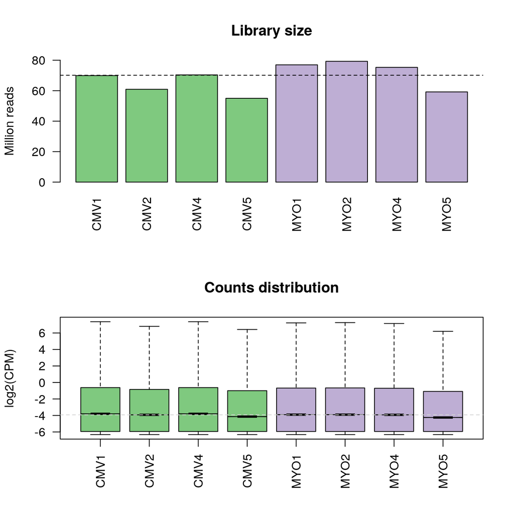

```r
colors2 <- brewer.pal(3, 'Accent')[c(1,2)]
condition_color <- c(rep(colors2[1], 4),rep(colors2[2], 4))
par(mfcol=c(2,1))
# Library size
read_counts <- featureCounts(dxd)
libsize <- colSums(read_counts)/1000000
barplot(libsize,
        ylim = c(0,80),
        names.arg=names(read_counts),
        col= condition_color,
        ylab = 'Million reads',
        main = 'Library size',
        las =2)
abline(h=median(libsize), lty=2)
# counts distribution b oxplot
logCPM <- log2((read_counts+1)/colSums(read_counts+1)*1e+06)
boxplot(logCPM,
        xlab='',
        ylab='log2(CPM)',
        notch   =T,
        col = condition_color,
        outline=FALSE,
        main = 'Counts distribution',
        las=2)
abline(h=median(as.matrix(logCPM)), lty=2, col='lightgrey')
```

**Samples density plot**

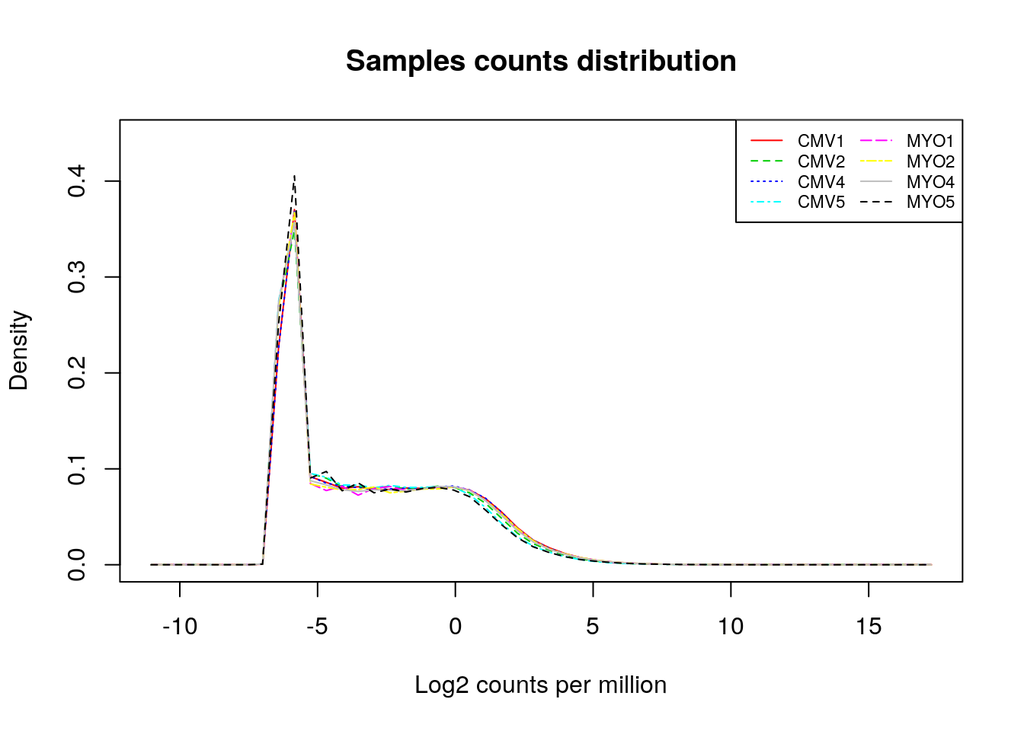

```r
condition <- c(rep('control', 4), rep('treatment', 4))
logCPM_dens <- data.frame(logCPM=as.vector(t(logCPM)),
                          samples=rep(colnames(logCPM), dim(logCPM)[1]),
                          condition=rep(condition, dim(logCPM)[1]))
# samples density plot
sm.density.compare(logCPM_dens$logCPM,
                   logCPM_dens$samples,
                   xlab='Log2 counts per million')
title(main='Samples counts distribution')
colfill<-c(2:(2+length(levels(logCPM_dens$samples))))
legend('topright',
       levels(logCPM_dens$samples),
       col=colfill,
       lty=c(1:length(logCPM_dens$samples)),
       lwd=1,
       ncol=2,
       cex=0.7)
```

Condition density plot

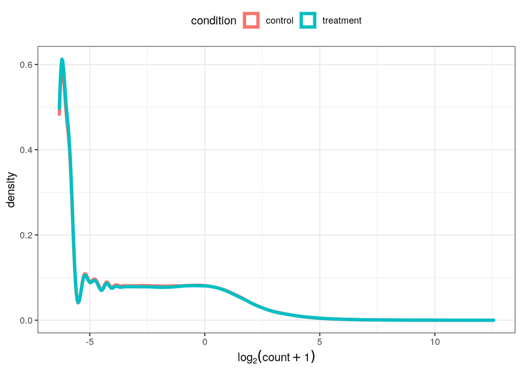

```r
ggplot(logCPM_dens, aes(x = logCPM, colour = condition)) +
  geom_density(alpha = 0.5, size = 1.5) + theme_bw() +
  theme(legend.position = 'top') + xlab(expression(log[2](count + 1)))
```

## Normalization & dispersion estimation

The same method as in DESeq2:

```r
ncores <- MulticoreParam(6)
dxd <- estimateSizeFactors(dxd)
dxd <- estimateDispersions(dxd, BPPARAM=ncores)
```

Plot dispersion:

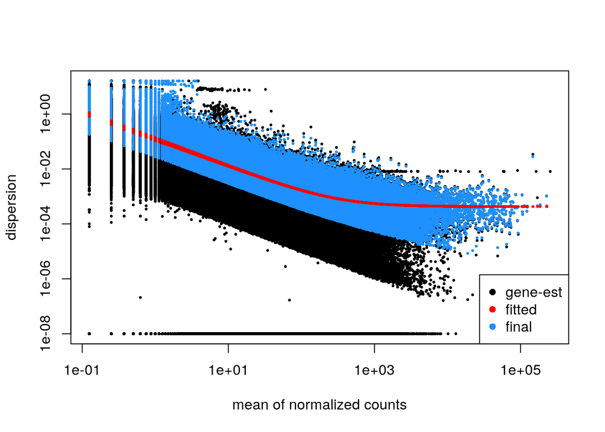

```r
plotDispEsts(dxd)
```

## Differential exon usage

### GLM

*DEXSeq* fits a generalized linear model with the formula `~ sample + exon + condition:exon` and compare it to the null model) `~ sample + exon`. The deviances of both fits are compared using a χ2-distribution, providing a p value.

We test whether the fraction of the genes reads that fall onto the exon under the test differs significantly between the experimental conditions.

```r
dxd <- testForDEU(dxd)
dxd <- estimateExonFoldChanges(dxd)
```

### Results

```r
dxr <- DEXSeqResults(dxd)
knitr::kable(head(dxr))
```

|  | groupID | featureID | exonBaseMean | dispersion | stat | pvalue | padj | control | treatment | log2fold_treatment_control | genomicData.seqnames | genomicData.start | genomicData.end | genomicData.width | genomicData.strand | countData.CMV1 | countData.CMV2 | countData.CMV4 | countData.CMV5 | countData.MYO1 | countData.MYO2 | countData.MYO4 | countData.MYO5 | transcripts |
| --- | --- | --- | --- | --- | --- | --- | --- | --- | --- | --- | --- | --- | --- | --- | --- | --- | --- | --- | --- | --- | --- | --- | --- | --- |
| ENSG00000000003.15_TSPAN6:E001 | ENSG00000000003.15_TSPAN6 | E001 | 0.7235569 | 0.0392633 | 5.4325679 | 0.0197646 | NA | 0.8074948 | 2.419947 | 3.1671674 | chrX | 100627108 | 100627108 | 1 | - | 0 | 0 | 1 | 0 | 2 | 1 | 1 | 1 | ENST0000…. |
| ENSG00000000003.15_TSPAN6:E002 | ENSG00000000003.15_TSPAN6 | E002 | 443.3238132 | 0.0002305 | 0.1675088 | 0.6823354 | 0.9664629 | 37.8295981 | 38.037063 | 0.0165781 | chrX | 100627109 | 100629986 | 2878 | - | 641 | 539 | 682 | 446 | 347 | 340 | 313 | 299 | ENST0000…. |
| ENSG00000000003.15_TSPAN6:E003 | ENSG00000000003.15_TSPAN6 | E003 | 169.3497355 | 0.0003023 | 0.0343997 | 0.8528592 | 0.9881447 | 23.8917219 | 23.745968 | -0.0180104 | chrX | 100630759 | 100630866 | 108 | - | 258 | 219 | 257 | 159 | 126 | 133 | 132 | 100 | ENST0000…. |
| ENSG00000000003.15_TSPAN6:E004 | ENSG00000000003.15_TSPAN6 | E004 | 0.5986611 | 0.2749383 | 0.0183540 | 0.8922347 | NA | 1.4006027 | 1.524385 | 0.2443777 | chrX | 100632063 | 100632068 | 6 | - | 0 | 2 | 1 | 0 | 0 | 2 | 0 | 0 | ENST0000…. |
| ENSG00000000003.15_TSPAN6:E005 | ENSG00000000003.15_TSPAN6 | E005 | 125.6599260 | 0.0003761 | 1.2426160 | 0.2649675 | 0.8287089 | 20.2720097 | 20.991507 | 0.1021478 | chrX | 100632485 | 100632540 | 56 | - | 161 | 156 | 191 | 131 | 96 | 102 | 103 | 81 | ENST0000…. |
| ENSG00000000003.15_TSPAN6:E006 | ENSG00000000003.15_TSPAN6 | E006 | 109.4825912 | 0.0003651 | 0.0182423 | 0.8925611 | 0.9921871 | 19.1614262 | 19.235707 | 0.0113093 | chrX | 100632541 | 100632568 | 28 | - | 151 | 135 | 163 | 121 | 80 | 91 | 84 | 65 | ENST0000…. |

Description of each column:

```r
mcols(dxr)$description
```

```
##  [1] "group/gene identifier"
##  [2] "feature/exon identifier"
##  [3] "mean of the counts across samples in each feature/exon"
##  [4] "exon dispersion estimate"
##  [5] "LRT statistic: full vs reduced"
##  [6] "LRT p-value: full vs reduced"
##  [7] "BH adjusted p-values"
##  [8] "exon usage coefficient"
##  [9] "exon usage coefficient"
## [10] "relative exon usage fold change"
## [11] "GRanges object of the coordinates of the exon/feature"
## [12] "matrix of integer counts, of each column containing a sample"
## [13] "list of transcripts overlapping with the exon"
```

### Exon level

How many exonic exons are significant with a false discovery rate of 1%?

```r
sum(dxr$padj < 0.01, na.rm = T)
```

```
## [1] 5836
```

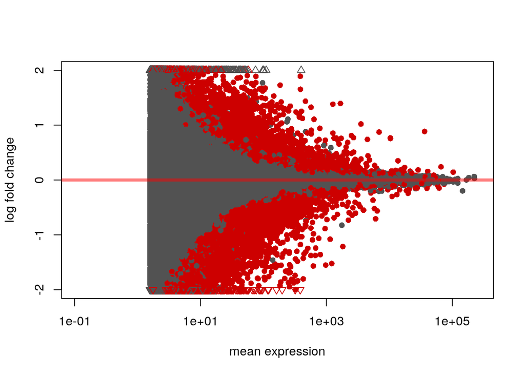

```r
plotMA(dxr, cex=1)
```

### Gene level

How many genes are affected?

```r
sum(tapply(dxr$padj < 0.01, dxr$groupID, any), na.rm = T)
```

```
## [1] 1985
```

DEXSeq returns one p-value for each exonic region. However, sometimes it is informative to know what is the FDR at the gene level, i.e. knowing the number of genes with at least one differentially used exon while keeping control of FDR.

```r
dxr_geneFDR <- perGeneQValue(dxr)
dxr_geneFDR <- as.data.frame(dxr_geneFDR[order(dxr_geneFDR)])
colnames(dxr_geneFDR) <- 'gene_level_FDR'
sum(dxr_geneFDR$gene_level_FDR < 0.01)
```

```
## [1] 1637
```

### Visualization

Test with **MYOCD**.

```r
head(dxr[order(dxr$padj),'groupID'])
```

```
## [1] "ENSG00000141052.18_MYOCD"
## [2] "ENSG00000196950.14_SLC39A10"
## [3] "ENSG00000197930.13_ERO1A"
## [4] "ENSG00000165494.11_PCF11+ENSG00000254676.1_AP000873.4"
## [5] "ENSG00000274266.1_SNORA73A+ENSG00000242125.3_SNHG3+ENSG00000180198.16_RCC1"
## [6] "ENSG00000232626.3_AC099336.1+ENSG00000077157.22_PPP1R12B"
```

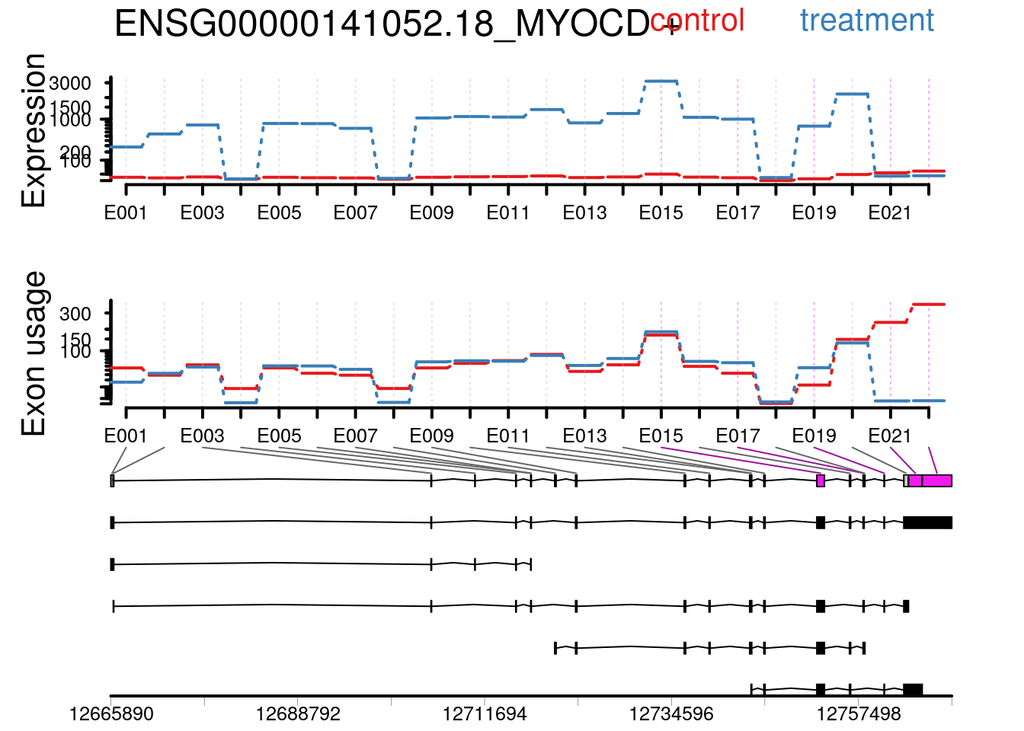

```r
plotDEXSeq(dxr, 'ENSG00000141052.18_MYOCD',
           displayTranscripts=TRUE,
           splicing=TRUE,
           legend=TRUE,
           cex.axis=1.2, cex=1.3, lwd=2 )
```

## Positive control genes

*MYH11*, *MCAM* and *SYNM* can be used to verify that *MYOCD* over-expression worked

There are also much less responsive target genes: *RRAS*, *RBPMS*, and *RBPMS2*.

We also have qPCR information in *MYH11, MCAM, KCNMB1*.

Differentially splicing of the following genes is of interest: *ACTN1, SMTN, NFIC, BICD2, TEAD1, TPM1, TPM2, PDLIM7, FHL1, CSR2, TGFB11, PKD1, MYL6, PDLIM5, FLNA, MBNL1, ZFR, FNBP1, SORBS1, PIP5K1C, TNRC18, SVIL, KLHL42, LARGE1, MICAL3*

```r
interesting_genes <- c('MYOCD', 'MYH11', 'MCAM', 'SYNM', 'RRAS', 'RBPMS', 'RBPMS2', 'KCNMB1',
                       'ACTN1', 'SMTN', 'NFIC', 'BICD2', 'TEAD1', 'TPM1', 'TPM2',
                       'PDLIM7', 'FHL1', 'CSR2', 'TGFB11', 'PKD1', 'MYL6', 'PDLIM5',
                       'FLNA', 'MBNL1', 'ZFR', 'FNBP1', 'SORBS1', 'PIP5K1C',
                       'TNRC18', 'SVIL', 'KLHL42', 'LARGE1', 'MICAL3')
```

Extract the results for these genes:

```r
interesting_genes_rows <- grep(paste(interesting_genes,collapse="|"), dxr$groupID)
dxr_interesting_genes <- dxr[interesting_genes_rows,]
knitr::kable(head(dxr_interesting_genes))
```

|  | groupID | featureID | exonBaseMean | dispersion | stat | pvalue | padj | control | treatment | log2fold_treatment_control | genomicData.seqnames | genomicData.start | genomicData.end | genomicData.width | genomicData.strand | countData.CMV1 | countData.CMV2 | countData.CMV4 | countData.CMV5 | countData.MYO1 | countData.MYO2 | countData.MYO4 | countData.MYO5 | transcripts |
| --- | --- | --- | --- | --- | --- | --- | --- | --- | --- | --- | --- | --- | --- | --- | --- | --- | --- | --- | --- | --- | --- | --- | --- | --- |
| ENSG00000008710.20_PKD1+ENSG00000284008.1_MIR6511B1:E001 | ENSG00000008710.20_PKD1+ENSG00000284008.1_MIR6511B1 | E001 | 3.11706 | 0.0123667 | 2.3400210 | 0.1260879 | 0.6836534 | 2.644834 | 3.711619 | 0.9780896 | chr16 | 2088708 | 2088709 | 2 | - | 0 | 3 | 2 | 2 | 6 | 6 | 2 | 4 | ENST0000…. |
| ENSG00000008710.20_PKD1+ENSG00000284008.1_MIR6511B1:E002 | ENSG00000008710.20_PKD1+ENSG00000284008.1_MIR6511B1 | E002 | 748.30302 | 0.0007798 | 0.3908414 | 0.5318575 | 0.9377581 | 49.584993 | 49.035310 | -0.0348923 | chr16 | 2088710 | 2089526 | 817 | - | 767 | 640 | 740 | 540 | 913 | 993 | 842 | 672 | ENST0000…. |
| ENSG00000008710.20_PKD1+ENSG00000284008.1_MIR6511B1:E003 | ENSG00000008710.20_PKD1+ENSG00000284008.1_MIR6511B1 | E003 | 958.43647 | 0.0002312 | 0.4574629 | 0.4988121 | 0.9291736 | 55.426587 | 54.949338 | -0.0275911 | chr16 | 2089527 | 2090194 | 668 | - | 939 | 792 | 963 | 733 | 1179 | 1244 | 1104 | 859 | ENST0000…. |
| ENSG00000008710.20_PKD1+ENSG00000284008.1_MIR6511B1:E004 | ENSG00000008710.20_PKD1+ENSG00000284008.1_MIR6511B1 | E004 | 520.34895 | 0.0000898 | 0.2021254 | 0.6530107 | 0.9615689 | 41.695344 | 41.393095 | -0.0222620 | chr16 | 2090285 | 2090590 | 306 | - | 500 | 425 | 509 | 417 | 634 | 675 | 574 | 494 | ENST0000…. |
| ENSG00000008710.20_PKD1+ENSG00000284008.1_MIR6511B1:E005 | ENSG00000008710.20_PKD1+ENSG00000284008.1_MIR6511B1 | E005 | 178.40646 | 0.0008801 | 0.0460438 | 0.8300962 | 0.9854630 | 24.674549 | 24.817263 | 0.0170004 | chr16 | 2090674 | 2090764 | 91 | - | 166 | 150 | 176 | 131 | 202 | 236 | 188 | 195 | ENST0000…. |
| ENSG00000008710.20_PKD1+ENSG00000284008.1_MIR6511B1:E006 | ENSG00000008710.20_PKD1+ENSG00000284008.1_MIR6511B1 | E006 | 108.23989 | 0.0010224 | 0.3284257 | 0.5665876 | 0.9451734 | 19.619519 | 19.194802 | -0.0639893 | chr16 | 2090765 | 2090808 | 44 | - | 114 | 88 | 112 | 77 | 124 | 141 | 104 | 118 | ENST0000…. |

How many genes are significant?

FDR< 0.01

```r
sum(tapply(dxr_interesting_genes$padj < 0.01, dxr_interesting_genes$groupID, any), na.rm = T)
```

```
## [1] 16
```

FDR< 0.05

```r
sum(tapply(dxr_interesting_genes$padj < 0.05, dxr_interesting_genes$groupID, any), na.rm = T)
```

```
## [1] 18
```

What are those genes?

```r
unique(dxr_interesting_genes[which(dxr_interesting_genes$padj < 0.05), 'groupID'])
```

```
##  [1] "ENSG00000022267.19_FHL1"
##  [2] "ENSG00000133424.21_LARGE1"
##  [3] "ENSG00000137942.16_FNBP1L"
##  [4] "ENSG00000140416.23_TPM1"
##  [5] "ENSG00000141052.18_MYOCD"
##  [6] "ENSG00000141905.19_NFIC"
##  [7] "ENSG00000152601.17_MBNL1"
##  [8] "ENSG00000157110.16_RBPMS"
##  [9] "ENSG00000163110.15_PDLIM5"
## [10] "ENSG00000187079.19_TEAD1"
## [11] "ENSG00000196465.10_MYL6B+ENSG00000092841.19_MYL6"
## [12] "ENSG00000196923.14_PDLIM7"
## [13] "ENSG00000196924.18_FLNA"
## [14] "ENSG00000197321.15_SVIL"
## [15] "ENSG00000198467.16_TPM2"
## [16] "ENSG00000224597.10_SVIL-AS1"
## [17] "ENSG00000258967.1_HMGN1P3+ENSG00000072110.14_ACTN1"
## [18] "ENSG00000278920.1_AC005005.4+ENSG00000240186.3_RN7SL633P+ENSG00000183963.18_SMTN"
```

## Write Results

### HTML Report

The results for of FDR<0.05 are exported to an HTML report:

```r
filePath <- 'results/reports/DEXSeqReport/'
dir.create(filePath, showWarnings = FALSE)

DEXSeqHTML(dxr, FDR=0.05, color=colors2,
           path=filePath,
           file='DEXSeq_results.html',
           BPPARAM=ncores)
```

### Exons

```r
write.table(dxr,'results/tables/DEXSeq/DEXSeq_results.csv',
            row.names = F, sep = '\t')
```

### Gene-level FDR

Write the gene-level FDR values to a file:

```r
write.table(dxr_geneFDR,
            'results/tables/DEXSeq/DEXSeq_results_geneFDR.csv',
            row.names = T, sep = '\t')
```

## Preprocessing using featureCounts

See https://github.com/vivekbhr/Subread_to_DEXSeq.

It seems like there is no benefits of using featureCounts with DEXSeq.